# Statistical Inference: Exploring the Exponential Distribution

Carl Fredriksson

## Overview

In this part of the project we will do some simulations. The aim of the simulations are to investigate the exponential distribution and compare it with the Central Limit Theorem.

### Simulations

Let us start by defining some constants and setting the seed so the simulations can be replicated.

```r
lambda = 0.2
n = 40
num_simulations = 1000
set.seed(1)
```

We can now run simulations of sampling from the exponential distribution and taking the mean for each sample.

```r
sample_means = NULL
for (i in 1 : num_simulations) sample_means = c(sample_means, mean(rexp(n, lambda)))
head(sample_means)
```

```
## [1] 4.860372 5.961285 4.279204 4.702298 5.196446 4.397114
```

Let us also simulate a large collection of random exponentials.

```r
exponentials = NULL
for (i in 1 : num_simulations) exponentials = c(exponentials, rexp(n, lambda))
head(exponentials)
```

```
## [1] 6.7905260 4.8846486 2.7681238 4.1226835 0.5983089 6.4075421
```

### Sample Mean versus Theoretical Mean

Let us compute the theoretical mean and the sample mean.

```r
m_p <- 1 / lambda
m_s <- mean(sample_means)
```

When we compare them we see that they are very similar.

| Theoretical | Sample |
| --- | --- |
| 5 | 4.990025 |

### Sample Variance versus Theoretical Variance

Let us compute the theoretical variance and the sample variance.

```r
v_p <- (1 / lambda)^2/n
v_s <- sd(sample_means)^2
```

As with the means, when we compare the variances we see that they are very similar.

| Theoretical | Sample |
| --- | --- |
| 0.625 | 0.6111165 |

### Distribution

Lets compare the sample means we simulated to the simulated exponentials.

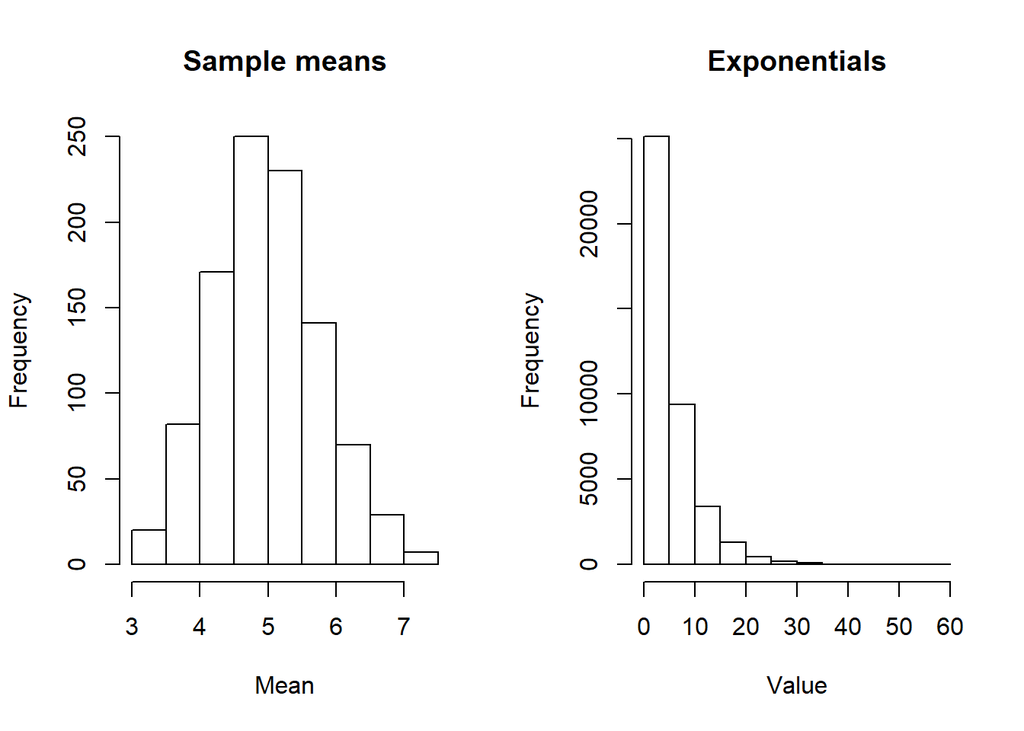

```r
par(mfrow=c(1, 2))
hist(sample_means, main="Sample means", xlab="Mean")
hist(exponentials, main="Exponentials", xlab="Value")
```

We can see that the sample means are approximately normally distributed, even though the underlying exponential distribution is skewed to the right. This is because of the Central Limit Theorem.